# Optimal Treatment Analysis

## Outcome Variable

**Outcome Variable:** ever_stunted

## Predictor Variables

**Intervention Variable:** mwtkg

**Adjustment Set:**

- arm
- W_mage
- meducyrs
- feducyrs
- single
- brthmon
- delta_W_mage
- delta_meducyrs
- delta_feducyrs
- delta_single
- delta_brthmon

## Stratifying Variables

The analysis was stratified on these variable(s):

- agecat
- studyid
- country

## Data Summary

| agecat | studyid | country | mwtkg | ever_stunted | n_cell | n |
| --- | --- | --- | --- | --- | --- | --- |
| 0-24 months | ki0047075b-MAL-ED | BANGLADESH | >=58 kg | 0 | 29 | 254 |
| 0-24 months | ki0047075b-MAL-ED | BANGLADESH | >=58 kg | 1 | 19 | 254 |
| 0-24 months | ki0047075b-MAL-ED | BANGLADESH | <52 kg | 0 | 49 | 254 |
| 0-24 months | ki0047075b-MAL-ED | BANGLADESH | <52 kg | 1 | 113 | 254 |
| 0-24 months | ki0047075b-MAL-ED | BANGLADESH | [52-58) kg | 0 | 21 | 254 |
| 0-24 months | ki0047075b-MAL-ED | BANGLADESH | [52-58) kg | 1 | 23 | 254 |
| 0-24 months | ki0047075b-MAL-ED | BRAZIL | >=58 kg | 0 | 110 | 221 |
| 0-24 months | ki0047075b-MAL-ED | BRAZIL | >=58 kg | 1 | 33 | 221 |
| 0-24 months | ki0047075b-MAL-ED | BRAZIL | <52 kg | 0 | 31 | 221 |
| 0-24 months | ki0047075b-MAL-ED | BRAZIL | <52 kg | 1 | 11 | 221 |
| 0-24 months | ki0047075b-MAL-ED | BRAZIL | [52-58) kg | 0 | 30 | 221 |
| 0-24 months | ki0047075b-MAL-ED | BRAZIL | [52-58) kg | 1 | 6 | 221 |
| 0-24 months | ki0047075b-MAL-ED | INDIA | >=58 kg | 0 | 23 | 242 |
| 0-24 months | ki0047075b-MAL-ED | INDIA | >=58 kg | 1 | 19 | 242 |
| 0-24 months | ki0047075b-MAL-ED | INDIA | <52 kg | 0 | 51 | 242 |
| 0-24 months | ki0047075b-MAL-ED | INDIA | <52 kg | 1 | 99 | 242 |
| 0-24 months | ki0047075b-MAL-ED | INDIA | [52-58) kg | 0 | 21 | 242 |
| 0-24 months | ki0047075b-MAL-ED | INDIA | [52-58) kg | 1 | 29 | 242 |
| 0-24 months | ki0047075b-MAL-ED | NEPAL | >=58 kg | 0 | 58 | 238 |
| 0-24 months | ki0047075b-MAL-ED | NEPAL | >=58 kg | 1 | 22 | 238 |
| 0-24 months | ki0047075b-MAL-ED | NEPAL | <52 kg | 0 | 37 | 238 |
| 0-24 months | ki0047075b-MAL-ED | NEPAL | <52 kg | 1 | 39 | 238 |
| 0-24 months | ki0047075b-MAL-ED | NEPAL | [52-58) kg | 0 | 61 | 238 |
| 0-24 months | ki0047075b-MAL-ED | NEPAL | [52-58) kg | 1 | 21 | 238 |
| 0-24 months | ki0047075b-MAL-ED | PERU | >=58 kg | 0 | 42 | 290 |
| 0-24 months | ki0047075b-MAL-ED | PERU | >=58 kg | 1 | 62 | 290 |
| 0-24 months | ki0047075b-MAL-ED | PERU | <52 kg | 0 | 42 | 290 |
| 0-24 months | ki0047075b-MAL-ED | PERU | <52 kg | 1 | 73 | 290 |
| 0-24 months | ki0047075b-MAL-ED | PERU | [52-58) kg | 0 | 20 | 290 |
| 0-24 months | ki0047075b-MAL-ED | PERU | [52-58) kg | 1 | 51 | 290 |

[output cut: 252 more lines]

The following strata were considered:

- agecat: 0-24 months, studyid: ki0047075b-MAL-ED, country: BANGLADESH
- agecat: 0-24 months, studyid: ki0047075b-MAL-ED, country: BRAZIL
- agecat: 0-24 months, studyid: ki0047075b-MAL-ED, country: INDIA
- agecat: 0-24 months, studyid: ki0047075b-MAL-ED, country: NEPAL
- agecat: 0-24 months, studyid: ki0047075b-MAL-ED, country: PERU
- agecat: 0-24 months, studyid: ki0047075b-MAL-ED, country: SOUTH AFRICA
- agecat: 0-24 months, studyid: ki0047075b-MAL-ED, country: TANZANIA, UNITED REPUBLIC OF
- agecat: 0-24 months, studyid: ki1000304b-SAS-CompFeed, country: INDIA
- agecat: 0-24 months, studyid: ki1017093-NIH-Birth, country: BANGLADESH
- agecat: 0-24 months, studyid: ki1017093b-PROVIDE, country: BANGLADESH
- agecat: 0-24 months, studyid: ki1017093c-NIH-Crypto, country: BANGLADESH
- agecat: 0-24 months, studyid: ki1066203-TanzaniaChild2, country: TANZANIA, UNITED REPUBLIC OF
- agecat: 0-24 months, studyid: ki1112895-iLiNS-Zinc, country: BURKINA FASO
- agecat: 0-24 months, studyid: ki1119695-PROBIT, country: BELARUS
- agecat: 0-24 months, studyid: ki1126311-ZVITAMBO, country: ZIMBABWE
- agecat: 0-24 months, studyid: ki1148112-LCNI-5, country: MALAWI
- agecat: 0-6 months, studyid: ki0047075b-MAL-ED, country: BANGLADESH
- agecat: 0-6 months, studyid: ki0047075b-MAL-ED, country: BRAZIL
- agecat: 0-6 months, studyid: ki0047075b-MAL-ED, country: INDIA
- agecat: 0-6 months, studyid: ki0047075b-MAL-ED, country: NEPAL
- agecat: 0-6 months, studyid: ki0047075b-MAL-ED, country: PERU
- agecat: 0-6 months, studyid: ki0047075b-MAL-ED, country: SOUTH AFRICA
- agecat: 0-6 months, studyid: ki0047075b-MAL-ED, country: TANZANIA, UNITED REPUBLIC OF
- agecat: 0-6 months, studyid: ki1000304b-SAS-CompFeed, country: INDIA
- agecat: 0-6 months, studyid: ki1017093-NIH-Birth, country: BANGLADESH
- agecat: 0-6 months, studyid: ki1017093b-PROVIDE, country: BANGLADESH
- agecat: 0-6 months, studyid: ki1017093c-NIH-Crypto, country: BANGLADESH
- agecat: 0-6 months, studyid: ki1066203-TanzaniaChild2, country: TANZANIA, UNITED REPUBLIC OF
- agecat: 0-6 months, studyid: ki1119695-PROBIT, country: BELARUS
- agecat: 0-6 months, studyid: ki1126311-ZVITAMBO, country: ZIMBABWE
- agecat: 0-6 months, studyid: ki1148112-LCNI-5, country: MALAWI
- agecat: 6-24 months, studyid: ki0047075b-MAL-ED, country: BANGLADESH
- agecat: 6-24 months, studyid: ki0047075b-MAL-ED, country: BRAZIL
- agecat: 6-24 months, studyid: ki0047075b-MAL-ED, country: INDIA
- agecat: 6-24 months, studyid: ki0047075b-MAL-ED, country: NEPAL
- agecat: 6-24 months, studyid: ki0047075b-MAL-ED, country: PERU
- agecat: 6-24 months, studyid: ki0047075b-MAL-ED, country: SOUTH AFRICA
- agecat: 6-24 months, studyid: ki0047075b-MAL-ED, country: TANZANIA, UNITED REPUBLIC OF
- agecat: 6-24 months, studyid: ki1000304b-SAS-CompFeed, country: INDIA
- agecat: 6-24 months, studyid: ki1017093-NIH-Birth, country: BANGLADESH
- agecat: 6-24 months, studyid: ki1017093b-PROVIDE, country: BANGLADESH
- agecat: 6-24 months, studyid: ki1017093c-NIH-Crypto, country: BANGLADESH
- agecat: 6-24 months, studyid: ki1066203-TanzaniaChild2, country: TANZANIA, UNITED REPUBLIC OF
- agecat: 6-24 months, studyid: ki1112895-iLiNS-Zinc, country: BURKINA FASO
- agecat: 6-24 months, studyid: ki1119695-PROBIT, country: BELARUS
- agecat: 6-24 months, studyid: ki1126311-ZVITAMBO, country: ZIMBABWE
- agecat: 6-24 months, studyid: ki1148112-LCNI-5, country: MALAWI

### Dropped Strata

Some strata were dropped due to rare outcomes:

- agecat: 6-24 months, studyid: ki0047075b-MAL-ED, country: BRAZIL

## Methods Detail

We’re interested in the causal parameters $E[Y_a]$ for all values of $a \in \mathcal{A}$. These parameters represent the mean outcome if, possibly contrary to fact, we intervened to set all units to have $A=a$. Under the randomization and positivity assumptions, these are identified by the statistical parameters $\psi_a=E_W[E_{Y|A,W}(Y|A=a,W)]$. In addition, we’re interested in the mean of $Y$, $E[Y]$ under no intervention (the observed mean). We will estimate these parameters by using SuperLearner to fit the relevant likelihood factors – $E_{Y|A,W}(Y|A=a,W)$ and $p(A=a|W)$, and then updating our likelihood fit using a joint TMLE.

For unadjusted analyses ($W=\{\}$), initial likelihoods were estimated using Lrnr_glm to estimate the simple $E(Y|A)$ and Lrnr_mean to estimate $p(A)$. For adjusted analyses, a small library containing Lrnr_glmnet, Lrnr_xgboost, and Lrnr_mean was used.

# Results Detail

## Results Plots

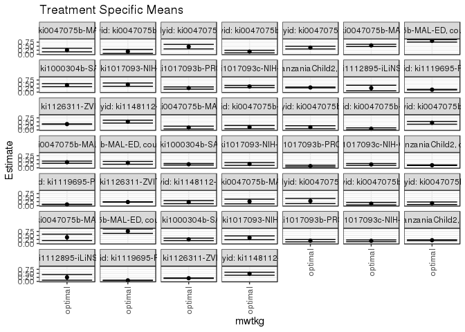

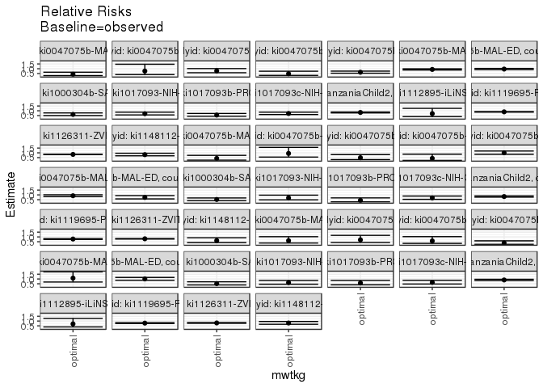

## Results Table

### Parameter: TSM

| agecat | studyid | country | intervention_level | baseline_level | estimate | ci_lower | ci_upper |
| --- | --- | --- | --- | --- | --- | --- | --- |
| 0-24 months | ki0047075b-MAL-ED | BANGLADESH | optimal | NA | 0.2613470 | 0.1482498 | 0.3744443 |
| 0-24 months | ki0047075b-MAL-ED | BRAZIL | optimal | NA | 0.1721435 | 0.0501169 | 0.2941702 |
| 0-24 months | ki0047075b-MAL-ED | INDIA | optimal | NA | 0.4698010 | 0.3271568 | 0.6124453 |
| 0-24 months | ki0047075b-MAL-ED | NEPAL | optimal | NA | 0.1647350 | 0.0831046 | 0.2463653 |
| 0-24 months | ki0047075b-MAL-ED | PERU | optimal | NA | 0.4092403 | 0.3244332 | 0.4940474 |
| 0-24 months | ki0047075b-MAL-ED | SOUTH AFRICA | optimal | NA | 0.5463512 | 0.4761660 | 0.6165364 |
| 0-24 months | ki0047075b-MAL-ED | TANZANIA, UNITED REPUBLIC OF | optimal | NA | 0.8298428 | 0.7547262 | 0.9049594 |
| 0-24 months | ki1000304b-SAS-CompFeed | INDIA | optimal | NA | 0.4294606 | 0.3338700 | 0.5250511 |
| 0-24 months | ki1017093-NIH-Birth | BANGLADESH | optimal | NA | 0.4635053 | 0.3610192 | 0.5659913 |
| 0-24 months | ki1017093b-PROVIDE | BANGLADESH | optimal | NA | 0.2503708 | 0.1804485 | 0.3202932 |
| 0-24 months | ki1017093c-NIH-Crypto | BANGLADESH | optimal | NA | 0.3469020 | 0.2809333 | 0.4128708 |
| 0-24 months | ki1066203-TanzaniaChild2 | TANZANIA, UNITED REPUBLIC OF | optimal | NA | 0.2857531 | 0.2622260 | 0.3092802 |
| 0-24 months | ki1112895-iLiNS-Zinc | BURKINA FASO | optimal | NA | 0.2510562 | 0.0778763 | 0.4242361 |
| 0-24 months | ki1119695-PROBIT | BELARUS | optimal | NA | 0.1505784 | 0.1329248 | 0.1682320 |
| 0-24 months | ki1126311-ZVITAMBO | ZIMBABWE | optimal | NA | 0.3641439 | 0.3518418 | 0.3764459 |
| 0-24 months | ki1148112-LCNI-5 | MALAWI | optimal | NA | 0.5163838 | 0.4257045 | 0.6070632 |
| 0-6 months | ki0047075b-MAL-ED | BANGLADESH | optimal | NA | 0.1463166 | 0.0585938 | 0.2340395 |
| 0-6 months | ki0047075b-MAL-ED | BRAZIL | optimal | NA | 0.1740104 | 0.0707370 | 0.2772838 |
| 0-6 months | ki0047075b-MAL-ED | INDIA | optimal | NA | 0.1688578 | 0.0750811 | 0.2626344 |
| 0-6 months | ki0047075b-MAL-ED | NEPAL | optimal | NA | 0.0726181 | 0.0161342 | 0.1291020 |
| 0-6 months | ki0047075b-MAL-ED | PERU | optimal | NA | 0.4423064 | 0.3566931 | 0.5279197 |
| 0-6 months | ki0047075b-MAL-ED | SOUTH AFRICA | optimal | NA | 0.3475824 | 0.2808339 | 0.4143308 |
| 0-6 months | ki0047075b-MAL-ED | TANZANIA, UNITED REPUBLIC OF | optimal | NA | 0.3065081 | 0.2192736 | 0.3937425 |
| 0-6 months | ki1000304b-SAS-CompFeed | INDIA | optimal | NA | 0.2198885 | 0.1714465 | 0.2683305 |
| 0-6 months | ki1017093-NIH-Birth | BANGLADESH | optimal | NA | 0.2389418 | 0.1505096 | 0.3273740 |
| 0-6 months | ki1017093b-PROVIDE | BANGLADESH | optimal | NA | 0.1063877 | 0.0551985 | 0.1575768 |
| 0-6 months | ki1017093c-NIH-Crypto | BANGLADESH | optimal | NA | 0.2079549 | 0.1509731 | 0.2649366 |
| 0-6 months | ki1066203-TanzaniaChild2 | TANZANIA, UNITED REPUBLIC OF | optimal | NA | 0.1605068 | 0.1418866 | 0.1791269 |
| 0-6 months | ki1119695-PROBIT | BELARUS | optimal | NA | 0.0757501 | 0.0645306 | 0.0869696 |
| 0-6 months | ki1126311-ZVITAMBO | ZIMBABWE | optimal | NA | 0.2268002 | 0.2160585 | 0.2375418 |
| 0-6 months | ki1148112-LCNI-5 | MALAWI | optimal | NA | 0.2205015 | 0.1231313 | 0.3178718 |
| 6-24 months | ki0047075b-MAL-ED | BANGLADESH | optimal | NA | 0.2593638 | 0.1141097 | 0.4046178 |
| 6-24 months | ki0047075b-MAL-ED | INDIA | optimal | NA | 0.2884926 | 0.1281879 | 0.4487974 |
| 6-24 months | ki0047075b-MAL-ED | NEPAL | optimal | NA | 0.1226441 | 0.0437017 | 0.2015865 |
| 6-24 months | ki0047075b-MAL-ED | PERU | optimal | NA | 0.1481966 | 0.0690520 | 0.2273413 |
| 6-24 months | ki0047075b-MAL-ED | SOUTH AFRICA | optimal | NA | 0.3843692 | 0.1876884 | 0.5810499 |
| 6-24 months | ki0047075b-MAL-ED | TANZANIA, UNITED REPUBLIC OF | optimal | NA | 0.7666027 | 0.6278824 | 0.9053229 |
| 6-24 months | ki1000304b-SAS-CompFeed | INDIA | optimal | NA | 0.2588168 | 0.1830418 | 0.3345918 |
| 6-24 months | ki1017093-NIH-Birth | BANGLADESH | optimal | NA | 0.3566007 | 0.2381279 | 0.4750736 |
| 6-24 months | ki1017093b-PROVIDE | BANGLADESH | optimal | NA | 0.1738051 | 0.1013808 | 0.2462294 |
| 6-24 months | ki1017093c-NIH-Crypto | BANGLADESH | optimal | NA | 0.1688787 | 0.1117299 | 0.2260275 |
| 6-24 months | ki1066203-TanzaniaChild2 | TANZANIA, UNITED REPUBLIC OF | optimal | NA | 0.2046266 | 0.1802901 | 0.2289630 |
| 6-24 months | ki1112895-iLiNS-Zinc | BURKINA FASO | optimal | NA | 0.2498722 | 0.0728010 | 0.4269435 |
| 6-24 months | ki1119695-PROBIT | BELARUS | optimal | NA | 0.0626379 | 0.0508280 | 0.0744477 |
| 6-24 months | ki1126311-ZVITAMBO | ZIMBABWE | optimal | NA | 0.1973415 | 0.1847968 | 0.2098861 |
| 6-24 months | ki1148112-LCNI-5 | MALAWI | optimal | NA | 0.4756637 | 0.3825306 | 0.5687969 |

### Parameter: E(Y)

| agecat | studyid | country | intervention_level | baseline_level | estimate | ci_lower | ci_upper |
| --- | --- | --- | --- | --- | --- | --- | --- |
| 0-24 months | ki0047075b-MAL-ED | BANGLADESH | observed | NA | 0.6150353 | 0.5549404 | 0.6751302 |
| 0-24 months | ki0047075b-MAL-ED | BRAZIL | observed | NA | 0.2268665 | 0.1715790 | 0.2821541 |
| 0-24 months | ki0047075b-MAL-ED | INDIA | observed | NA | 0.6098230 | 0.5481713 | 0.6714746 |
| 0-24 months | ki0047075b-MAL-ED | NEPAL | observed | NA | 0.3463989 | 0.2858974 | 0.4069004 |
| 0-24 months | ki0047075b-MAL-ED | PERU | observed | NA | 0.6461056 | 0.5908120 | 0.7013991 |
| 0-24 months | ki0047075b-MAL-ED | SOUTH AFRICA | observed | NA | 0.5888470 | 0.5300483 | 0.6476458 |
| 0-24 months | ki0047075b-MAL-ED | TANZANIA, UNITED REPUBLIC OF | observed | NA | 0.8600513 | 0.8173835 | 0.9027191 |
| 0-24 months | ki1000304b-SAS-CompFeed | INDIA | observed | NA | 0.6907381 | 0.6499108 | 0.7315654 |
| 0-24 months | ki1017093-NIH-Birth | BANGLADESH | observed | NA | 0.6653616 | 0.6284343 | 0.7022889 |
| 0-24 months | ki1017093b-PROVIDE | BANGLADESH | observed | NA | 0.4515150 | 0.4137778 | 0.4892523 |
| 0-24 months | ki1017093c-NIH-Crypto | BANGLADESH | observed | NA | 0.4806788 | 0.4450201 | 0.5163376 |
| 0-24 months | ki1066203-TanzaniaChild2 | TANZANIA, UNITED REPUBLIC OF | observed | NA | 0.3468755 | 0.3276401 | 0.3661108 |
| 0-24 months | ki1112895-iLiNS-Zinc | BURKINA FASO | observed | NA | 0.3574927 | 0.3075312 | 0.4074543 |
| 0-24 months | ki1119695-PROBIT | BELARUS | observed | NA | 0.1694426 | 0.1504514 | 0.1884339 |
| 0-24 months | ki1126311-ZVITAMBO | ZIMBABWE | observed | NA | 0.4357254 | 0.4265437 | 0.4449071 |
| 0-24 months | ki1148112-LCNI-5 | MALAWI | observed | NA | 0.6362846 | 0.6036893 | 0.6688798 |
| 0-6 months | ki0047075b-MAL-ED | BANGLADESH | observed | NA | 0.3489372 | 0.2903032 | 0.4075712 |
| 0-6 months | ki0047075b-MAL-ED | BRAZIL | observed | NA | 0.1854007 | 0.1340351 | 0.2367664 |
| 0-6 months | ki0047075b-MAL-ED | INDIA | observed | NA | 0.3454237 | 0.2854913 | 0.4053561 |
| 0-6 months | ki0047075b-MAL-ED | NEPAL | observed | NA | 0.1721520 | 0.1240767 | 0.2202273 |
| 0-6 months | ki0047075b-MAL-ED | PERU | observed | NA | 0.4404704 | 0.3832220 | 0.4977188 |
| 0-6 months | ki0047075b-MAL-ED | SOUTH AFRICA | observed | NA | 0.3821394 | 0.3240917 | 0.4401871 |
| 0-6 months | ki0047075b-MAL-ED | TANZANIA, UNITED REPUBLIC OF | observed | NA | 0.4177265 | 0.3571892 | 0.4782638 |
| 0-6 months | ki1000304b-SAS-CompFeed | INDIA | observed | NA | 0.4228562 | 0.3938145 | 0.4518978 |
| 0-6 months | ki1017093-NIH-Birth | BANGLADESH | observed | NA | 0.3498010 | 0.3125026 | 0.3870995 |
| 0-6 months | ki1017093b-PROVIDE | BANGLADESH | observed | NA | 0.2465965 | 0.2139083 | 0.2792846 |
| 0-6 months | ki1017093c-NIH-Crypto | BANGLADESH | observed | NA | 0.3032168 | 0.2704053 | 0.3360283 |
| 0-6 months | ki1066203-TanzaniaChild2 | TANZANIA, UNITED REPUBLIC OF | observed | NA | 0.1943938 | 0.1784001 | 0.2103874 |
| 0-6 months | ki1119695-PROBIT | BELARUS | observed | NA | 0.0969955 | 0.0840038 | 0.1099872 |
| 0-6 months | ki1126311-ZVITAMBO | ZIMBABWE | observed | NA | 0.2817802 | 0.2734460 | 0.2901145 |
| 0-6 months | ki1148112-LCNI-5 | MALAWI | observed | NA | 0.3583743 | 0.3011925 | 0.4155560 |
| 6-24 months | ki0047075b-MAL-ED | BANGLADESH | observed | NA | 0.4232781 | 0.3462846 | 0.5002715 |
| 6-24 months | ki0047075b-MAL-ED | INDIA | observed | NA | 0.4120983 | 0.3343364 | 0.4898601 |
| 6-24 months | ki0047075b-MAL-ED | NEPAL | observed | NA | 0.2105984 | 0.1532575 | 0.2679394 |
| 6-24 months | ki0047075b-MAL-ED | PERU | observed | NA | 0.4003552 | 0.3214396 | 0.4792708 |
| 6-24 months | ki0047075b-MAL-ED | SOUTH AFRICA | observed | NA | 0.3522426 | 0.2767244 | 0.4277608 |
| 6-24 months | ki0047075b-MAL-ED | TANZANIA, UNITED REPUBLIC OF | observed | NA | 0.7627324 | 0.6949974 | 0.8304674 |
| 6-24 months | ki1000304b-SAS-CompFeed | INDIA | observed | NA | 0.4997058 | 0.4552059 | 0.5442056 |
| 6-24 months | ki1017093-NIH-Birth | BANGLADESH | observed | NA | 0.5746266 | 0.5223700 | 0.6268832 |
| 6-24 months | ki1017093b-PROVIDE | BANGLADESH | observed | NA | 0.3002171 | 0.2581653 | 0.3422689 |
| 6-24 months | ki1017093c-NIH-Crypto | BANGLADESH | observed | NA | 0.2635890 | 0.2251977 | 0.3019802 |
| 6-24 months | ki1066203-TanzaniaChild2 | TANZANIA, UNITED REPUBLIC OF | observed | NA | 0.2280473 | 0.2073097 | 0.2487849 |
| 6-24 months | ki1112895-iLiNS-Zinc | BURKINA FASO | observed | NA | 0.3569790 | 0.3070175 | 0.4069406 |
| 6-24 months | ki1119695-PROBIT | BELARUS | observed | NA | 0.0799572 | 0.0655484 | 0.0943660 |
| 6-24 months | ki1126311-ZVITAMBO | ZIMBABWE | observed | NA | 0.2464648 | 0.2363994 | 0.2565303 |
| 6-24 months | ki1148112-LCNI-5 | MALAWI | observed | NA | 0.5987512 | 0.5631238 | 0.6343786 |

### Parameter: RR

| agecat | studyid | country | intervention_level | baseline_level | estimate | ci_lower | ci_upper |
| --- | --- | --- | --- | --- | --- | --- | --- |
| 0-24 months | ki0047075b-MAL-ED | BANGLADESH | optimal | observed | 0.4249302 | 0.2829027 | 0.6382607 |
| 0-24 months | ki0047075b-MAL-ED | BRAZIL | optimal | observed | 0.7587876 | 0.3916488 | 1.4700891 |
| 0-24 months | ki0047075b-MAL-ED | INDIA | optimal | observed | 0.7703891 | 0.5843633 | 1.0156343 |
| 0-24 months | ki0047075b-MAL-ED | NEPAL | optimal | observed | 0.4755643 | 0.3056822 | 0.7398580 |
| 0-24 months | ki0047075b-MAL-ED | PERU | optimal | observed | 0.6333954 | 0.5327539 | 0.7530489 |
| 0-24 months | ki0047075b-MAL-ED | SOUTH AFRICA | optimal | observed | 0.9278322 | 0.8678257 | 0.9919878 |
| 0-24 months | ki0047075b-MAL-ED | TANZANIA, UNITED REPUBLIC OF | optimal | observed | 0.9648759 | 0.9016202 | 1.0325695 |
| 0-24 months | ki1000304b-SAS-CompFeed | INDIA | optimal | observed | 0.6217415 | 0.4982181 | 0.7758901 |
| 0-24 months | ki1017093-NIH-Birth | BANGLADESH | optimal | observed | 0.6966216 | 0.5665694 | 0.8565264 |
| 0-24 months | ki1017093b-PROVIDE | BANGLADESH | optimal | observed | 0.5545127 | 0.4272753 | 0.7196399 |
| 0-24 months | ki1017093c-NIH-Crypto | BANGLADESH | optimal | observed | 0.7216919 | 0.6094289 | 0.8546349 |
| 0-24 months | ki1066203-TanzaniaChild2 | TANZANIA, UNITED REPUBLIC OF | optimal | observed | 0.8237916 | 0.7786997 | 0.8714946 |
| 0-24 months | ki1112895-iLiNS-Zinc | BURKINA FASO | optimal | observed | 0.7022693 | 0.3933130 | 1.2539179 |
| 0-24 months | ki1119695-PROBIT | BELARUS | optimal | observed | 0.8886688 | 0.8609577 | 0.9172717 |
| 0-24 months | ki1126311-ZVITAMBO | ZIMBABWE | optimal | observed | 0.8357187 | 0.8155762 | 0.8563586 |
| 0-24 months | ki1148112-LCNI-5 | MALAWI | optimal | observed | 0.8115612 | 0.6895554 | 0.9551539 |
| 0-6 months | ki0047075b-MAL-ED | BANGLADESH | optimal | observed | 0.4193208 | 0.2376327 | 0.7399232 |
| 0-6 months | ki0047075b-MAL-ED | BRAZIL | optimal | observed | 0.9385638 | 0.5602592 | 1.5723116 |
| 0-6 months | ki0047075b-MAL-ED | INDIA | optimal | observed | 0.4888424 | 0.2929539 | 0.8157151 |
| 0-6 months | ki0047075b-MAL-ED | NEPAL | optimal | observed | 0.4218255 | 0.2069252 | 0.8599086 |
| 0-6 months | ki0047075b-MAL-ED | PERU | optimal | observed | 1.0041683 | 0.8482045 | 1.1888099 |
| 0-6 months | ki0047075b-MAL-ED | SOUTH AFRICA | optimal | observed | 0.9095696 | 0.8169275 | 1.0127177 |
| 0-6 months | ki0047075b-MAL-ED | TANZANIA, UNITED REPUBLIC OF | optimal | observed | 0.7337530 | 0.5811497 | 0.9264280 |
| 0-6 months | ki1000304b-SAS-CompFeed | INDIA | optimal | observed | 0.5200078 | 0.3992345 | 0.6773165 |
| 0-6 months | ki1017093-NIH-Birth | BANGLADESH | optimal | observed | 0.6830792 | 0.4811495 | 0.9697551 |
| 0-6 months | ki1017093b-PROVIDE | BANGLADESH | optimal | observed | 0.4314242 | 0.2724751 | 0.6830966 |
| 0-6 months | ki1017093c-NIH-Crypto | BANGLADESH | optimal | observed | 0.6858291 | 0.5353500 | 0.8786056 |
| 0-6 months | ki1066203-TanzaniaChild2 | TANZANIA, UNITED REPUBLIC OF | optimal | observed | 0.8256786 | 0.7626922 | 0.8938666 |
| 0-6 months | ki1119695-PROBIT | BELARUS | optimal | observed | 0.7809650 | 0.7389563 | 0.8253618 |
| 0-6 months | ki1126311-ZVITAMBO | ZIMBABWE | optimal | observed | 0.8048832 | 0.7768602 | 0.8339170 |
| 0-6 months | ki1148112-LCNI-5 | MALAWI | optimal | observed | 0.6152828 | 0.4135618 | 0.9153961 |
| 6-24 months | ki0047075b-MAL-ED | BANGLADESH | optimal | observed | 0.6127503 | 0.3672840 | 1.0222684 |
| 6-24 months | ki0047075b-MAL-ED | INDIA | optimal | observed | 0.7000579 | 0.4212485 | 1.1634014 |
| 6-24 months | ki0047075b-MAL-ED | NEPAL | optimal | observed | 0.5823599 | 0.3293319 | 1.0297912 |
| 6-24 months | ki0047075b-MAL-ED | PERU | optimal | observed | 0.3701629 | 0.2309107 | 0.5933920 |
| 6-24 months | ki0047075b-MAL-ED | SOUTH AFRICA | optimal | observed | 1.0912059 | 0.6828151 | 1.7438545 |
| 6-24 months | ki0047075b-MAL-ED | TANZANIA, UNITED REPUBLIC OF | optimal | observed | 1.0050742 | 0.8684726 | 1.1631617 |
| 6-24 months | ki1000304b-SAS-CompFeed | INDIA | optimal | observed | 0.5179384 | 0.3795284 | 0.7068250 |
| 6-24 months | ki1017093-NIH-Birth | BANGLADESH | optimal | observed | 0.6205782 | 0.4550207 | 0.8463731 |
| 6-24 months | ki1017093b-PROVIDE | BANGLADESH | optimal | observed | 0.5789314 | 0.3928627 | 0.8531266 |
| 6-24 months | ki1017093c-NIH-Crypto | BANGLADESH | optimal | observed | 0.6406895 | 0.4751912 | 0.8638271 |
| 6-24 months | ki1066203-TanzaniaChild2 | TANZANIA, UNITED REPUBLIC OF | optimal | observed | 0.8972987 | 0.8328274 | 0.9667609 |
| 6-24 months | ki1112895-iLiNS-Zinc | BURKINA FASO | optimal | observed | 0.6999633 | 0.3847729 | 1.2733450 |
| 6-24 months | ki1119695-PROBIT | BELARUS | optimal | observed | 0.7833922 | 0.7337371 | 0.8364076 |
| 6-24 months | ki1126311-ZVITAMBO | ZIMBABWE | optimal | observed | 0.8006880 | 0.7638838 | 0.8392655 |
| 6-24 months | ki1148112-LCNI-5 | MALAWI | optimal | observed | 0.7944264 | 0.6627844 | 0.9522150 |